# Collate historical Baltic Sea trawl survey data

```r
  filter(!(haul.id == "2007:4:EST:CEV:TVS:1:6" & LngtCm == 19 & IndWgt == 185)) |>
  filter(!(haul.id == "2007:4:EST:CEV:TVS:1:5" & LngtCm == 20 & IndWgt == 175)) |>
  filter(!(haul.id == "2007:4:EST:CEV:TVS:1:5" & LngtCm == 19 & IndWgt == 165)) |>
  filter(!(haul.id == "2007:4:EST:CEV:TVS:1:3" & LngtCm == 22 & IndWgt == 37)) |>
  filter(!(haul.id == "2009:4:EST:CEV:TVS:2:4" & LngtCm == 11 & IndWgt == 117)) |>
  filter(!(haul.id == "2009:4:EST:CEV:TVS:2:4" & LngtCm == 11 & IndWgt == 135)) |>
  filter(!(haul.id == "2009:4:EST:CEV:TVS:2:1" & LngtCm == 20 & IndWgt == 31)) |>
  filter(!(haul.id == "2009:4:EST:CEV:TVS:2:1" & LngtCm == 20 & IndWgt == 37)) |>
  filter(!(haul.id == "2009:4:EST:CEV:TVS:2:1" & LngtCm == 19 & IndWgt == 32)) |>
  filter(!(haul.id == "2009:4:EST:CEV:TVS:2:1" & LngtCm == 19 & IndWgt == 36)) |>
  filter(!(haul.id == "2009:4:EST:CEV:TVS:2:1" & LngtCm == 29 & IndWgt == 137)) |>
  filter(!(haul.id == "2010:4:EST:CEV:TVS:1:8" & LngtCm == 29 & IndWgt == 133)) |>
  filter(!(haul.id == "2014:4:EST:CEV:TVS:1:4" & LngtCm == 11 & IndWgt == 52)) |>
  filter(!(haul.id == "2014:4:EST:CEV:TVS:1:4" & LngtCm == 20 & IndWgt == 193)) |>
  filter(!(haul.id == "2014:4:EST:CEV:TVS:1:4" & LngtCm == "18" & IndWgt == "179.5")) |>
  filter(!(haul.id == "2014:4:EST:CEV:TVS:1:4" & LngtCm == 23 & IndWgt == 56.5)) |>
  filter(!(haul.id == "1994:2:LAT:MONL:DT:000001:14" & LngtCm == 25 & IndWgt == 420)) |>
  filter(!(haul.id == "2009:1:RUS:ATL:TVL:57:6" & LngtCm == 24 & IndWgt == 460)) |>
  filter(!(haul.id == "2012:1:DEN:DAN2:TVL:222:41" & LngtCm == 25 & IndWgt == 476)) |>
  filter(!(haul.id == "2012:1:DEN:DAN2:TVL:222:41" & LngtCm == 25 & IndWgt == 470)) |>
  filter(!(haul.id == "2012:1:DEN:DAN2:TVL:222:41" & LngtCm == 25 & IndWgt == 424)) |>
  filter(!(haul.id == "2013:1:DEN:DAN2:TVL:113:4" & LngtCm == "25.2" & IndWgt == "546")) |>
  filter(!(haul.id == "2009:1:RUS:ATL:TVL:57:34" & LngtCm == 24 & IndWgt == 460)) |>
  filter(!(haul.id == "2016:1:DEN:DAN2:TVL:53:10" & LngtCm == 20 & IndWgt == 490)) |>
  filter(!(haul.id == "2015:1:GFR:SOL2:TVS:24067:19" & LngtCm == 32 & IndWgt == 137)) |>
  filter(!(haul.id == "2017:1:GFR:SOL2:TVS:24321:26" & LngtCm == 23 & IndWgt == 413)) |>
  filter(!(haul.id == "2008:4:DEN:DAN2:TVL:63:30"))

caflo |>
  filter(LngtCm <= 25 & IndWgt >= 400 & LngtCm >= 20)
```

```
# A tibble: 0 × 33
# ℹ 33 variables: RecordType <fct>, Survey <fct>, Quarter <fct>, Country <fct>,
#   Ship <fct>, Gear <fct>, SweepLngt <int>, GearExp <fct>, DoorType <lgl>,
#   StNo <chr>, HaulNo <int>, Year <dbl>, SpecCodeType <chr>, SpecCode <int>,
#   AreaType <int>, AreaCode <fct>, LngtCode <fct>, LngtClas <int>, Sex <fct>,
#   Maturity <fct>, PlusGr <fct>, Age <int>, NoAtALK <int>, IndWgt <dbl>,
#   DateofCalculation <int>, Valid_Aphia <int>, StatRec <fct>, LngtCm <dbl>,
#   Species <fct>, haul.id <fct>, SD <fct>, Rect <chr>, HaulVal <fct>
```

```r
capla <- capla |>
  filter(!(haul.id == "2009:1:DEN:DAN2:TVL:92:48" & LngtCm == 33)) |>
  filter(!(haul.id == "2014:4:GFR:SOL2:TVS:24039:28" & LngtCm == 25)) |>
  filter(!(haul.id == "2012:1:DEN:DAN2:TVL:172:14" & LngtCm == 1)) |>
  filter(!(haul.id == "2012:1:DEN:DAN2:TVL:172:14" & LngtCm == 2)) |>
  filter(!(haul.id == "2009:1:DEN:DAN2:TVL:146:10" & LngtCm == 49)) |>
  filter(!(haul.id == "2009:1:DEN:DAN2:TVL:140:7" & LngtCm == 40)) |>
  filter(!(haul.id == "2009:1:DEN:DAN2:TVL:140:7" & LngtCm == 42))

# ML: for whiting and dab (the new species I added), I'll filter using a different method
# Dab
# ggplot(cadab, aes(LngtCm, IndWgt)) +
#   geom_point() +
#   facet_wrap(~Year) +
#   ggtitle("dab")

cadab <- cadab |>
  filter(!(LngtCm > 20 & IndWgt < 50)) |>
  filter(!(LngtCm > 30 & IndWgt < 160))

# ggplot(cadab, aes(LngtCm, IndWgt)) +
#   geom_point() +
#   facet_wrap(~Year) +
#   ggtitle("dab")

# Turbot
# ggplot(catur, aes(LngtCm, IndWgt)) +
#   geom_point() +
#   facet_wrap(~Year) +
#   ggtitle("turbot")

catur <- catur |>
  filter(LngtCm < 100)

# ggplot(catur, aes(LngtCm, IndWgt)) +
#   geom_point() +
#   facet_wrap(~Year) +
#   ggtitle("turbot")

# Whiting
# ggplot(cawhi, aes(LngtCm, IndWgt)) +
#   geom_point() +
#   facet_wrap(~Year) +
#   ggtitle("whiting")

cawhi <- cawhi |>
  filter(!(LngtCm < 30 & IndWgt > 300)) |>
  filter(!(LngtCm < 25 & IndWgt > 150))

# ggplot(cawhi, aes(LngtCm, IndWgt)) +
#   geom_point() +
#   facet_wrap(~Year) +
#   ggtitle("whiting")
```

## Swedish CA data

Next we read in the individual data (“CA” data) from the Swedish data. We need this to convert CPUE in numbers to CPUE in weight later. Note we only have data that are not already on DATRAS for cod and flounder! And note that these CA data only go back to 1988.

```r
######## load fiskdata2 (fd2) individual data for cod and flounder
cacodfd2 <- read.csv(paste0(home, "/data/trawl-data-historical/Fiskdata2/trawlsurv_s_Torsk.csv"), sep = ";")
caflofd2 <- read.csv(paste0(home, "/data/trawl-data-historical/Fiskdata2/trawlsurv_s_Skrubba.csv"), sep = ";")

cacodfd21 <- read.csv(paste0(home, "/data/trawl-data-historical/Fiskdata2/trawl_surveys_(s)BITSCOD.csv"), sep = ";")
caflofd21 <- read.csv(paste0(home, "/data/trawl-data-historical/Fiskdata2/trawl_surveys_(s)BITSFLOUNDER.csv"), sep = ";")


###### merge them
cacodfd2 <- rbind(cacodfd2[, -17], cacodfd21[, c(1:17, 19, 22:24)])
caflofd2 <- rbind(caflofd2[, -17], caflofd21[, c(1:17, 19, 22:24)])

###### change length in cm

cacodfd2$Lengthcl <- cacodfd2$Lengthcl / 10
caflofd2$Lengthcl <- caflofd2$Lengthcl / 10

###### create a new index to match them

cacodfd2$idx <- paste(cacodfd2$Date, cacodfd2$Haul, sep = ".")
caflofd2$idx <- paste(caflofd2$Date, caflofd2$Haul, sep = ".")
index <- cbind(index, do.call("rbind", strsplit(as.character(index$index), "[.]")))
index$idx2 <- paste(index$"1", index$"3", sep = ".")

#### match lat and long

cacodfd2$LATDD <- index[match(cacodfd2$idx, index$idx2), "LATDD"]
cacodfd2$LONGDD <- index[match(cacodfd2$idx, index$idx2), "LONGDD"]
caflofd2$LATDD <- index[match(caflofd2$idx, index$idx2), "LATDD"]
caflofd2$LONGDD <- index[match(caflofd2$idx, index$idx2), "LONGDD"]

##### remove invalid and calibration hauls

cacodfd2 <- cacodfd2[!cacodfd2$Validity %in% type, ]
caflofd2 <- caflofd2[!caflofd2$Validity %in% type, ]

##### remove length =0 and weight=0 and NAs in lat and long

cacodfd2 <- cacodfd2 |>
  filter(Lengthcl != 0) |>
  filter(!(is.na(Weight))) |>
  filter(!(is.na(LATDD)))

# summary(cacodfd2)

caflofd2 <- caflofd2 |>
  filter(Lengthcl != 0) |>
  filter(!(is.na(Weight))) |>
  filter(!(is.na(LATDD)))

# summary(caflofd2)


##### match ICES rect
caflofd2$Rect <- mapplots::ices.rect2(caflofd2$LONGDD, caflofd2$LATDD)
cacodfd2$Rect <- mapplots::ices.rect2(cacodfd2$LONGDD, cacodfd2$LATDD)

##### SD
pts <- SpatialPoints(cbind(caflofd2$LONGDD, caflofd2$LATDD),
  proj4string = CRS(proj4string(xx))
)

caflofd2$SD <- over(pts, xx)$Area_27

caflofd2 <- caflofd2 |>
  mutate(
    SD = factor(SD),
    SD = fct_recode(SD,
      "20" = "3.a.20",
      "21" = "3.a.21",
      "22" = "3.c.22",
      "23" = "3.b.23",
      "24" = "3.d.24",
      "25" = "3.d.25",
      "26" = "3.d.26",
      "27" = "3.d.27",
      "28" = "3.d.28.1",
      "28" = "3.d.28.2",
      "29" = "3.d.29"
    )
  )
pts <- SpatialPoints(cbind(cacodfd2$LONGDD, cacodfd2$LATDD),
  proj4string = CRS(proj4string(xx))
)

cacodfd2$SD <- over(pts, xx)$Area_27

cacodfd2 <- cacodfd2 |>
  mutate(
    SD = factor(SD),
    SD = fct_recode(SD,
      "20" = "3.a.20",
      "21" = "3.a.21",
      "22" = "3.c.22",
      "23" = "3.b.23",
      "24" = "3.d.24",
      "25" = "3.d.25",
      "26" = "3.d.26",
      "27" = "3.d.27",
      "28" = "3.d.28.1",
      "28" = "3.d.28.2",
      "29" = "3.d.29"
    )
  )
###### check for outliers

# ggplot(data=cacodfd2, aes(x=Lengthcl, y=Weight))+geom_point(color="red",size=1) +facet_wrap(~Year)+ggtitle("cod")
# ggplot(data=caflofd2, aes(x=Lengthcl, y=Weight))+geom_point(color="red",size=1) +facet_wrap(~Year)+ggtitle("flounder")
#
# ggplot(data=cacodfd2, aes(x=Lengthcl, y=Weight))+geom_point(color="red",size=1) +facet_grid(SD~Year)+ggtitle("cod")
# ggplot(data=caflofd2, aes(x=Lengthcl, y=Weight))+geom_point(color="red",size=1) +facet_grid(SD~Year)+ggtitle("flounder")


###### clean outliers

caflofd2 <- caflofd2 |>
  filter(!(Year == 2002 & Lengthcl == 10)) |>
  filter(!(Year == 2010 & Lengthcl == 22 & Weight == 396)) |>
  filter(!(Year == 2016 & Lengthcl == 19 & Weight == 720)) |>
  filter(!(Year == 2016 & Lengthcl == 37 & Weight == 206)) |>
  filter(!(Year == 2008 & Lengthcl == 39 & Weight == 258))


###### merge L/W of cod and flounder
# ML: I want to keep the coordinates in the individual files!

lwcod <- cacod |>
  filter(Year <= 2016) |>
  dplyr::select(Year, SD, LngtCm, IndWgt, haul.id) |>
  left_join(HHdata |>
    dplyr::select(haul.id, lon, lat, Quarter, Month, Day), by = "haul.id") # ML: adding lat-lon!

lwflo <- caflo |>
  filter(Year <= 2016) |>
  dplyr::select(Year, SD, LngtCm, IndWgt, haul.id) |>
  left_join(HHdata |>
    dplyr::select(haul.id, lon, lat, Quarter, Month, Day), by = "haul.id") # ML: adding lat-lon!

lwcod2 <- cacodfd2 |>
  dplyr::select(Year, SD, Lengthcl, Weight, idx, LONGDD, LATDD, Date) |> # ML: keeping lat-lon!
  rename(
    lat = LATDD,
    lon = LONGDD
  ) |>
  mutate(
    quarter = quarter(Date),
    month = month(Date),
    day = day(Date),
    idx = as.factor(idx)
  ) |>
  dplyr::select(-Date)

names(lwcod2) <- names(lwcod)

lwflo2 <- caflofd2 |>
  dplyr::select(Year, SD, Lengthcl, Weight, idx, LONGDD, LATDD, Date) |> # ML: keeping lat-lon!
  rename(
    lat = LATDD,
    lon = LONGDD
  ) |>
  mutate(
    quarter = quarter(Date),
    month = month(Date),
    day = day(Date),
    idx = as.factor(idx)
  ) |>
  dplyr::select(-Date)

names(lwflo2) <- names(lwflo)

lwcodT <- rbind(lwcod, lwcod2)
lwfloT <- rbind(lwflo, lwflo2)

###### check for outliers

# ggplot(data=lwcodT, aes(x=LngtCm, y=IndWgt))+geom_point(color="red",size=3) +facet_wrap(~Year)+ggtitle("cod")
# ggplot(data=lwfloT, aes(x=LngtCm, y=IndWgt))+geom_point(color="red",size=3) +facet_wrap(~Year)+ggtitle("flounder")
#
# ggplot(data=lwcodT, aes(x=LngtCm, y=IndWgt))+geom_point(color="red",size=3) +facet_grid(SD~Year)+ggtitle("cod")
# ggplot(data=lwfloT, aes(x=LngtCm, y=IndWgt))+geom_point(color="red",size=3) +facet_grid(SD~Year)+ggtitle("flounder")
```

## Historical Latvian

Read the historical Latvian data. Note, here we also only have cod and flounder

```r
######## Historical Latvian data

####### HH_LAT

HH_LAT <- read.csv(paste0(home, "/data/trawl-data-historical/Datras/Historic Latvian/HH_LAT.csv"), sep = ";")

names(HH_LAT)
```

```
 [1] "RecordType"     "Quarter"        "Country"        "Ship"
 [5] "Gear"           "SweepLngt"      "GearExp"        "DoorType"
 [9] "StNo"           "HaulNo"         "Year"           "month"
[13] "Day"            "TimeShot"       "Stratum"        "HaulDur"
[17] "DayNight"       "ShootLat"       "ShootLong"      "HaulLat"
[21] "HaulLong"       "StatRec"        "Depth"          "HaulVal"
[25] "HydroStNo"      "StdSpecRecCode" "BycSpecRecCode" "DataType"
[29] "Netopening"     "Rigging"        "Tickler"        "Distance"
[33] "Warplngt"       "Warpdia"        "WarpDen"        "DoorSurface"
[37] "DoorWgt"        "DoorSpread"     "WingSpread"     "Buoyancy"
[41] "KiteDim"        "WgtGroundRope"  "TowDir"         "GroundSpeed"
[45] "SpeedWater"     "SurCurDir"      "SurCurSpeed"    "BotCurDir"
[49] "BotCurSpeed"    "WindDir"        "WindSpeed"      "SwellDir"
[53] "SwellHeight"    "SurTemp"        "BotTemp"        "SurSal"
[57] "BotSal"         "ThermoCline"    "ThClineDepth"
```

```r
#### create haul.id

HH_LAT$haul.id <- paste(HH_LAT$Year, HH_LAT$Quarter, HH_LAT$Country, HH_LAT$Ship, HH_LAT$Gear, HH_LAT$StNo, HH_LAT$HaulNo, sep = ":")

HH_LAT$haul.id <- factor(HH_LAT$haul.id)

# levels(HH_LAT$haul.id)


###### select just valid, additional and no oxygen hauls

HH_LAT <- HH_LAT |>
  filter(HaulVal %in% c("A", "N", "V"))

##### select lat and long

HH_LAT$lat <- HH_LAT$ShootLat
HH_LAT$lon <- HH_LAT$ShootLong

##### fix one hauls that seems to south

HH_LAT$lat[HH_LAT$haul.id == "1978:1:LAT:4576:LBT:3:5"] <- 54.78
HH_LAT$ShootLat[HH_LAT$haul.id == "1978:1:LAT:4576:LBT:3:5"] <- 54.78
HH_LAT$HaulLat[HH_LAT$haul.id == "1978:1:LAT:4576:LBT:3:5"] <- 54.81


####### fix SD and ICES rect


pts <- SpatialPoints(cbind(HH_LAT$lon, HH_LAT$lat),
  proj4string = CRS(proj4string(xx))
)

HH_LAT$SD <- over(pts, xx)$Area_27

HH_LAT <- HH_LAT |>
  mutate(
    SD = factor(SD),
    SD = fct_recode(SD,
      "20" = "3.a.20",
      "21" = "3.a.21",
      "22" = "3.c.22",
      "23" = "3.b.23",
      "24" = "3.d.24",
      "25" = "3.d.25",
      "26" = "3.d.26",
      "27" = "3.d.27",
      "28" = "3.d.28.1",
      "28" = "3.d.28.2",
      "29" = "3.d.29"
    )
  )
HH_LAT$Rect <- mapplots::ices.rect2(HH_LAT$lon, HH_LAT$lat)


###### remove pelagic gear LPT

HH_LAT <- HH_LAT[!HH_LAT$Gear == "LPT", ]

# summary(HH_LAT)

##### there are 2 hauls with no depth registered. I will just put an aprox depth

HH_LAT[HH_LAT$Depth == "-9", ]
```

```
    RecordType Quarter Country Ship Gear SweepLngt GearExp DoorType StNo HaulNo
382         HH       4     LAT  ZBA  LBT        -9      -9       -9   11      4
467         HH       1     LAT  ZBA  LBT        -9      -9       -9    3     27
    Year month Day TimeShot Stratum HaulDur DayNight ShootLat ShootLong HaulLat
382 1981    11  28      750      -9      70        D  57.7500   22.4667 57.7167
467 1982     3  22      505      -9      30        D  58.4667   22.0833 58.5167
    HaulLong StatRec Depth HaulVal HydroStNo StdSpecRecCode BycSpecRecCode
382    22.35    44H2    -9       V        -9              1              1
467    22.05    45H2    -9       V        -9              1              1
    DataType Netopening Rigging Tickler Distance Warplngt Warpdia WarpDen
382        C         -9      -9      -9       -9      250      22      -9
467        C         -9      -9      -9       -9      250      22      -9
    DoorSurface DoorWgt DoorSpread WingSpread Buoyancy KiteDim WgtGroundRope
382           3     580         -9         -9       -9      -9            -9
467           3     580         -9         -9       -9      -9            -9
    TowDir GroundSpeed SpeedWater SurCurDir SurCurSpeed BotCurDir BotCurSpeed
382    240         3.8         -9        -9          -9        -9          -9
467     -9         4.0         -9        -9          -9        -9          -9
    WindDir WindSpeed SwellDir SwellHeight SurTemp BotTemp SurSal BotSal
382     158         4       -9         0.5      -9      -9     -9     -9
467       0         0       -9         0.0      -9      -9     -9     -9
    ThermoCline ThClineDepth                 haul.id     lat     lon SD Rect
382          -9           -9 1981:4:LAT:ZBA:LBT:11:4 57.7500 22.4667 28 44H2
467          -9           -9 1982:1:LAT:ZBA:LBT:3:27 58.4667 22.0833 28 45H2
```

```r
HH_LAT$Depth[HH_LAT$haul.id == "1981:4:LAT:ZBA:LBT:11:4"] <- 10
HH_LAT$Depth[HH_LAT$haul.id == "1982:1:LAT:ZBA:LBT:3:27"] <- 18



####### HL_LAT

HL_LAT <- read.csv(paste0(home, "/data/trawl-data-historical/Datras/Historic Latvian/HL_LAT.csv"), sep = ";")

HL_LAT |>
  summarise(n = n(), .by = Species) |>
  arrange(desc(n))
```

```
             Species     n
1       Gadus morhua 35290
2 Platichthys flesus  3713
```

```r
names(HL_LAT)
```

```
 [1] "RecordType"    "Quarter"       "Country"       "Ship"
 [5] "Gear"          "SweepLngt"     "GearExp"       "DoorType"
 [9] "StNo"          "HaulNo"        "Year"          "SpecCodeType"
[13] "SpecCode"      "SpecVal"       "Sex"           "TotalNo"
[17] "CatIdentifier" "NoMeas"        "SubFactor"     "SubWgt"
[21] "CatCatchWgt"   "LngtCode"      "LngtClass"     "HLNoAtLngt"
[25] "Species"
```

```r
#### create haul.id

HL_LAT$haul.id <- paste(HL_LAT$Year, HL_LAT$Quarter, HL_LAT$Country, HL_LAT$Ship, HL_LAT$Gear, HL_LAT$StNo, HL_LAT$HaulNo, sep = ":")

HL_LAT$haul.id <- factor(HL_LAT$haul.id)

# levels(HL_LAT$haul.id)


###### select just the hauls in HH_LAT

HL_LAT <- HL_LAT[HL_LAT$haul.id %in% HH_LAT$haul.id, ]


#### match haul SD, rect, haul validity, StdSpecRecCode and BycSpecRecCode and haul duration

HL_LAT$SD <- HH_LAT[match(HL_LAT$haul.id, HH_LAT$haul.id), "SD"]
HL_LAT$Rect <- HH_LAT[match(HL_LAT$haul.id, HH_LAT$haul.id), "Rect"]
HL_LAT$HaulVal <- HH_LAT[match(HL_LAT$haul.id, HH_LAT$haul.id), "HaulVal"]
HL_LAT$StdSpecRecCode <- HH_LAT[match(HL_LAT$haul.id, HH_LAT$haul.id), "StdSpecRecCode"]
HL_LAT$BycSpecRecCode <- HH_LAT[match(HL_LAT$haul.id, HH_LAT$haul.id), "BycSpecRecCode"]
HL_LAT$HaulDur <- HH_LAT[match(HL_LAT$haul.id, HH_LAT$haul.id), "HaulDur"]
HL_LAT$DataType <- HH_LAT[match(HL_LAT$haul.id, HH_LAT$haul.id), "DataType"]


# summary(HL_LAT$HaulVal)
# summary(HH_LAT$HaulVal)

####### select different species

HL_LATcod <- HL_LAT |>
  filter(Species == "Gadus morhua")

HL_LATflo <- HL_LAT |>
  filter(Species == "Platichthys flesus")


##### add 0 catches
#### common columns for merging
comcol <- intersect(names(HL_LATcod), names(HH_LAT))
comcol <- comcol[-c(1)]

##### for cod add 0s and then remove lines with SpecVal = 0
HL_LATcod0 <- merge(HL_LATcod, HH_LAT[, comcol], by = comcol, all = TRUE)
# summary(HL_LATcod0)

HL_LATcod0$SpecVal[is.na(HL_LATcod0$SpecVal)] <- "zeroCatch"
HL_LATcod0$SpecVal <- factor(HL_LATcod0$SpecVal)

HL_LATcod0 <- HL_LATcod0 |>
  filter(SpecVal != "0")

HL_LATcod0$Species <- "Gadus morhua"

##### for flounder add 0s, remove them if StdSpecRecCode !=1 and then remove lines with SpecVal = 0
HL_LATflo0 <- merge(HL_LATflo, HH_LAT[, comcol], by = comcol, all = TRUE)
# summary(HL_LATflo0)

HL_LATflo0 <- HL_LATflo0[!(is.na(HL_LATflo0$Species) & HL_LATflo0$StdSpecRecCode != 1), ]

HL_LATflo0$SpecVal[is.na(HL_LATflo0$SpecVal)] <- "zeroCatch"
HL_LATflo0$SpecVal <- factor(HL_LATflo0$SpecVal)

HL_LATflo0 <- HL_LATflo0 |>
  filter(SpecVal != "0")

HL_LATflo0$Species <- "Platichthys flesus"


#### check number of hauls for each species
n_distinct(HH_LAT$haul.id)
```

```
[1] 1303
```

```r
n_distinct(HL_LATcod0$haul.id)
```

```
[1] 1300
```

```r
n_distinct(HL_LATflo0$haul.id)
```

```
[1] 1303
```

```r
####### create CPUE unstandardized for SpecVal=1. If DataType = C then CPUEun=HLNoAtLngt, if DataType=R then CPUEun=HLNoAtLngt/(HaulDur/60), if DataType = S then CPUEun=(HLNoAtLngt*SubFactor)/(HaulDur/60). If SpecVal="zeroCatch" then CPUEun=0, if SpecVal=4 we need to decide.


#### cod
HL_LATcod0 <- HL_LATcod0 |>
  mutate(CPUEun = ifelse(SpecVal == "1" & DataType == "C", HLNoAtLngt, ifelse(SpecVal == "1" & DataType == "R", HLNoAtLngt / (HaulDur / 60), ifelse(SpecVal == "1" & DataType == "S", (HLNoAtLngt * SubFactor) / (HaulDur / 60), ifelse(SpecVal == "zeroCatch", 0, NA)))))

##### create the data.frame with records without LFD

HL_LATcod4 <- HL_LATcod0 |>
  filter(SpecVal == "4")

##### create the HL with LFD

HL_LATcodL <- HL_LATcod0 |>
  filter(!SpecVal == "4")

#### flounder
HL_LATflo0 <- HL_LATflo0 |>
  mutate(CPUEun = ifelse(SpecVal == "1" & DataType == "C", HLNoAtLngt, ifelse(SpecVal == "1" & DataType == "R", HLNoAtLngt / (HaulDur / 60), ifelse(SpecVal == "1" & DataType == "S", (HLNoAtLngt * SubFactor) / (HaulDur / 60), ifelse(SpecVal == "zeroCatch", 0, NA)))))

##### create the data.frame with records without LFD

HL_LATflo4 <- HL_LATflo0 |>
  filter(SpecVal == "4")

##### create the HL with LFD

HL_LATfloL <- HL_LATflo0 |>
  filter(!SpecVal == "4")

######### CA_LAT

CA_LAT <- read.csv(paste0(home, "/data/trawl-data-historical/Datras/Historic Latvian/CA_LAT.csv"), sep = ";")

unique(CA_LAT$NoAtALK)
```

```
[1] 1
```

```r
CA_LAT |>
  summarise(n = n(), .by = Species) |>
  arrange(desc(n))
```

```
             Species     n
1       Gadus morhua 52175
2 Platichthys flesus  8506
```

```r
names(CA_LAT)
```

```
 [1] "RecordType"   "Quarter"      "Country"      "Ship"         "Gear"
 [6] "SweepLngt"    "GearExp"      "DoorType"     "StNo"         "HaulNo"
[11] "Year"         "SpecCodeType" "SpecCode"     "AreaType"     "AreaCode"
[16] "LngtCode"     "LngtClas"     "Sex"          "Maturity"     "PlusGr"
[21] "Age"          "NoAtALK"      "IndWgt"       "Species"
```

```r
#### create haul.id

CA_LAT$haul.id <- paste(CA_LAT$Year, CA_LAT$Quarter, CA_LAT$Country, CA_LAT$Ship, CA_LAT$Gear, CA_LAT$StNo, CA_LAT$HaulNo, sep = ":")

CA_LAT$haul.id <- factor(CA_LAT$haul.id)

# levels(CA_LAT$haul.id)


###### select just the hauls in HH_LAT

CA_LAT <- CA_LAT[CA_LAT$haul.id %in% HH_LAT$haul.id, ]


#### match haul SD, rect, haul validity

CA_LAT$SD <- HH_LAT[match(CA_LAT$haul.id, HH_LAT$haul.id), "SD"]
CA_LAT$Rect <- HH_LAT[match(CA_LAT$haul.id, HH_LAT$haul.id), "Rect"]
CA_LAT$HaulVal <- HH_LAT[match(CA_LAT$haul.id, HH_LAT$haul.id), "HaulVal"]

####### select different species remove missing individual weights or weight = 0
CA_LATcod <- CA_LAT |>
  filter(Species == "Gadus morhua" & IndWgt != 0 & !(is.na(IndWgt))) |>
  left_join(HH_LAT |> dplyr::select(haul.id, lat, lon, Quarter, month, Day)) # ML: add in coordinates!

CA_LATflo <- CA_LAT |>
  filter(Species == "Platichthys flesus" & IndWgt != 0 & !(is.na(IndWgt))) |>
  left_join(HH_LAT |> dplyr::select(haul.id, lat, lon, Quarter, month, Day)) # ML: add in coordinates!


###### check for outliers

# ggplot(data=CA_LATcod, aes(x=LngtClas, y=IndWgt))+geom_point(color="red",size=3) +facet_wrap(~Year)+ggtitle("cod")
# ggplot(data=CA_LATflo, aes(x=LngtClas, y=IndWgt))+geom_point(color="red",size=3) +facet_wrap(~Year)+ggtitle("flounder")
# ggplot(data=CA_LATcod, aes(x=LngtClas, y=IndWgt))+geom_point(color="red",size=3) +facet_grid(SD~Year)+ggtitle("cod")
# ggplot(data=CA_LATflo, aes(x=LngtClas, y=IndWgt))+geom_point(color="red",size=3) +facet_grid(SD~Year)+ggtitle("flounder")


###### clean outliers

CA_LATcod <- CA_LATcod |>
  filter(!(haul.id == "1990:1:LAT:ZBA:LBT:3:12" & LngtClas == 107)) |>
  filter(!(haul.id == "1978:2:LAT:4576:LBT:4:1" & LngtClas == 83)) |>
  filter(!(haul.id == "1978:2:LAT:4576:LBT:4:3" & LngtClas == 85)) |>
  filter(!(haul.id == "1983:2:LAT:ZBA:LBT:4:23" & IndWgt == 7410)) |>
  filter(!(haul.id == "1984:1:LAT:ZBA:LBT:1:24" & LngtClas == 97)) |>
  filter(!(haul.id == "1985:1:LAT:ZBA:LBT:1:20" & LngtClas == 52 & IndWgt == 3805)) |>
  filter(!(haul.id == "1989:1:LAT:ZBA:LBT:3:13" & LngtClas == 47 & IndWgt == 11355)) |>
  filter(!(haul.id == "1989:1:LAT:ZBA:LBT:1:22" & LngtClas == 49 & IndWgt == 4030)) |>
  filter(!(haul.id == "1989:1:LAT:ZBA:LBT:3:2" & LngtClas == 66 & IndWgt == 980)) |>
  filter(!(haul.id == "1989:4:LAT:ZBA:LBT:12:6" & LngtClas == 88 & IndWgt == 2950)) |>
  filter(!(haul.id == "1982:4:LAT:ZBA:LBT:11:34" & LngtClas == 83 & IndWgt == 400)) |>
  filter(!(haul.id == "1980:2:LAT:ZBA:LBT:4:25" & LngtClas == 60 & IndWgt == 300)) |>
  filter(!(haul.id == "1980:2:LAT:ZBA:LBT:4:22" & LngtClas == 54 & IndWgt == 570)) |>
  filter(!(haul.id == "1982:1:LAT:ZBA:LBT:3:19" & LngtClas == 63 & IndWgt == 4680)) |>
  filter(!(haul.id == "1984:1:LAT:ZBA:LBT:1:14" & LngtClas == 99 & IndWgt == 560)) |>
  filter(!(haul.id == "1984:2:LAT:ZBA:LBT:6:16" & LngtClas == 44 & IndWgt == 7300)) |>
  filter(!(haul.id == "1984:2:LAT:ZBA:LBT:6:16" & LngtClas == 41 & IndWgt == 6100)) |>
  filter(!(haul.id == "1987:2:LAT:ZBA:LBT:4:26" & LngtClas == 32 & IndWgt == 2700)) |>
  filter(!(haul.id == "1983:2:LAT:ZBA:LBT:4:11" & LngtClas == 70 & IndWgt == 200)) |>
  filter(!(haul.id == "1983:2:LAT:ZBA:LBT:4:11" & LngtClas == 4 & IndWgt == 550))





CA_LATflo <- CA_LATflo |>
  filter(!(haul.id == "1990:1:LAT:ZBA:LBT:3:27" & LngtClas == 28 & IndWgt == 23.6)) |>
  filter(!(haul.id == "1990:1:LAT:ZBA:LBT:3:14" & LngtClas == 21 & IndWgt == 950)) |>
  filter(!(haul.id == "1983:1:LAT:ZBA:LBT:3:14" & LngtClas == 23 & IndWgt == 360)) |>
  filter(!(haul.id == "1986:1:LAT:BPE:LBT:3:23" & LngtClas == 26 & IndWgt == 760)) |>
  filter(!(haul.id == "1989:1:LAT:ZBA:LBT:3:13" & LngtClas == 27 & IndWgt == 960)) |>
  filter(!(haul.id == "1989:2:LAT:ZBA:LBT:4:23" & LngtClas == 29 & IndWgt == 32.8)) |>
  filter(!(haul.id == "1990:1:LAT:ZBA:LBT:3:31" & LngtClas == 28 & IndWgt == 894)) |>
  filter(!(haul.id == "1981:4:LAT:ZBA:LBT:11:41" & LngtClas == 30 & IndWgt == 715)) |>
  filter(!(haul.id == "1982:1:LAT:ZBA:LBT:3:31" & LngtClas == 19 & IndWgt == 340)) |>
  filter(!(haul.id == "1983:2:LAT:ZBA:LBT:4:13" & LngtClas == 29 & IndWgt == 28.6)) |>
  filter(!(haul.id == "1983:2:LAT:ZBA:LBT:4:13" & LngtClas == 35 & IndWgt == 160)) |>
  filter(!(haul.id == "1986:2:LAT:BPE:LBT:5:9" & LngtClas == 35 & IndWgt == 46.7)) |>
  filter(!(haul.id == "1986:2:LAT:BPE:LBT:5:5" & LngtClas == 27 & IndWgt == 533)) |>
  filter(!(haul.id == "1985:2:LAT:ZBA:LBT:4:27" & LngtClas == 31 & IndWgt == 27.4)) |>
  filter(!(haul.id == "1984:1:LAT:ZBA:LBT:3:47" & LngtClas == 24 & IndWgt == 620)) |>
  filter(!(haul.id == "1984:1:LAT:ZBA:LBT:3:47" & LngtClas == 24 & IndWgt == 360)) |>
  filter(!(haul.id == "1984:1:LAT:ZBA:LBT:3:45" & LngtClas == 22 & IndWgt == 320)) |>
  filter(!(haul.id == "1984:1:LAT:ZBA:LBT:3:47" & LngtClas == 26 & IndWgt == 780)) |>
  filter(!(haul.id == "1984:1:LAT:ZBA:LBT:3:47" & LngtClas == 28 & IndWgt == 770)) |>
  filter(!(haul.id == "1984:1:LAT:ZBA:LBT:3:47" & LngtClas == 26 & IndWgt == 670)) |>
  filter(!(haul.id == "1984:1:LAT:ZBA:LBT:3:47" & LngtClas == 26 & IndWgt == 600)) |>
  filter(!(haul.id == "1984:1:LAT:ZBA:LBT:3:47" & LngtClas == 29 & IndWgt == 540)) |>
  filter(!(haul.id == "1984:1:LAT:ZBA:LBT:3:47" & LngtClas == 29 & IndWgt == 530)) |>
  filter(!(haul.id == "1984:1:LAT:ZBA:LBT:3:45" & LngtClas == 32 & IndWgt == 134)) |>
  filter(!(haul.id == "1984:1:LAT:ZBA:LBT:3:47" & LngtClas == 35 & IndWgt == 134)) |>
  filter(!(haul.id == "1984:1:LAT:ZBA:LBT:3:47" & LngtClas == 34 & IndWgt == 200)) |>
  filter(!(haul.id == "1984:1:LAT:ZBA:LBT:3:47" & LngtClas == 35 & IndWgt == 950)) |>
  filter(!(haul.id == "1984:1:LAT:ZBA:LBT:3:47" & LngtClas == 35 & IndWgt == 770)) |>
  filter(!(haul.id == "1984:1:LAT:ZBA:LBT:3:47" & LngtClas == 36 & IndWgt == 250)) |>
  filter(!(haul.id == "1984:1:LAT:ZBA:LBT:3:47" & LngtClas == 36 & IndWgt == 300)) |>
  filter(!(haul.id == "1984:1:LAT:ZBA:LBT:3:47" & LngtClas == 38 & IndWgt == 340)) |>
  filter(!(haul.id == "1984:1:LAT:ZBA:LBT:3:47" & LngtClas == 37 & IndWgt == 370)) |>
  filter(!(haul.id == "1984:2:LAT:27:LBT:4:23" & LngtClas == 37 & IndWgt == 380)) |>
  filter(!(haul.id == "1984:1:LAT:ZBA:LBT:3:45" & LngtClas == 36 & IndWgt == 410)) |>
  filter(!(haul.id == "1984:2:LAT:27:LBT:4:35" & LngtClas == 36 & IndWgt == 450)) |>
  filter(!(haul.id == "1984:1:LAT:ZBA:LBT:3:47" & LngtClas == 41 & IndWgt == 200)) |>
  filter(!(haul.id == "1984:1:LAT:ZBA:LBT:3:47" & LngtClas == 42 & IndWgt == 260)) |>
  filter(!(haul.id == "1984:2:LAT:27:LBT:4:22" & LngtClas == 42 & IndWgt == 620))
```

## Combine and save CA

Combine all individual data (CA) and save cod and flounder. Since the rest of the species only have what is available on DATRAS, there’s no need to save them.

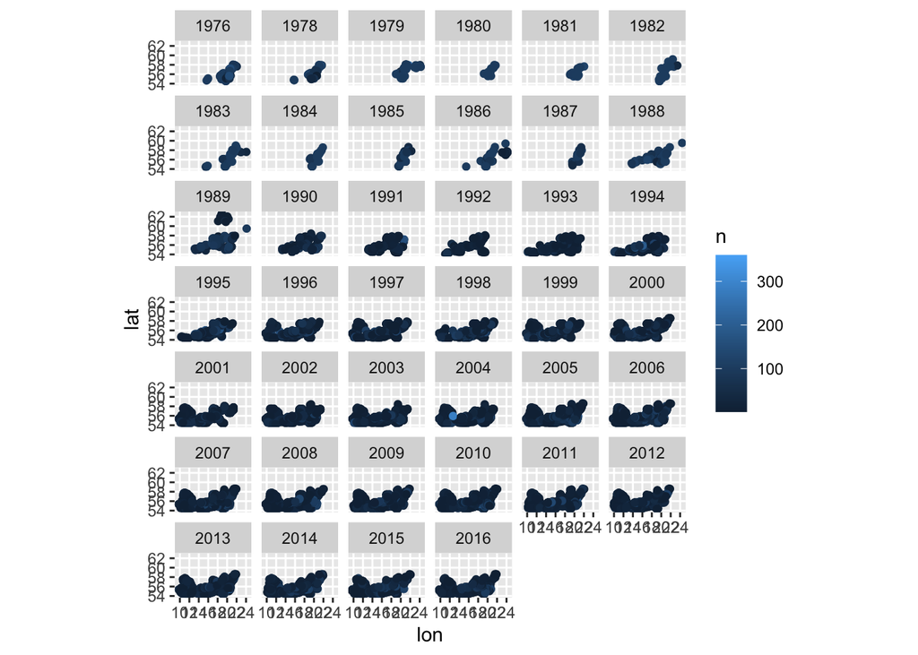

```r
###### merge all the CA
lwcod3 <- CA_LATcod |>
  filter(Year <= 2016) |>
  dplyr::select(Year, SD, LngtClas, IndWgt, haul.id, lon, lat, Quarter, month, Day) |>
  rename(LngtCm = LngtClas) |>
  rename(Month = month)

lwflo3 <- CA_LATflo |>
  filter(Year <= 2016) |>
  dplyr::select(Year, SD, LngtClas, IndWgt, haul.id, lon, lat, Quarter, month, Day) |>
  rename(LngtCm = LngtClas) |>
  rename(Month = month)

lwcodTotal <- rbind(lwcod, lwcod2, lwcod3)
lwfloTotal <- rbind(lwflo, lwflo2, lwflo3)

# Plot in space
lwcodTotal |>
  summarise(n = n(), .by = c(Year, lat, lon)) |>
  ggplot(aes(lon, lat, color = n)) +
  geom_point() +
  facet_wrap(~Year, ncol = 6) +
  coord_sf()
```

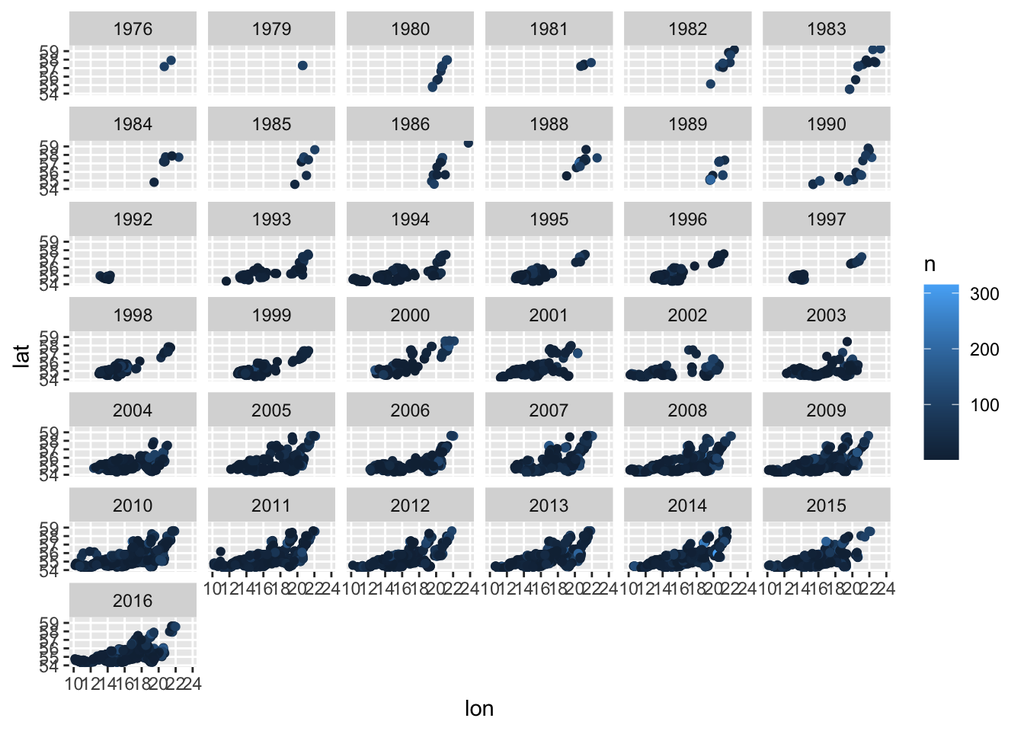

```r
lwfloTotal |>
  summarise(n = n(), .by = c(Year, lat, lon)) |>
  ggplot(aes(lon, lat, color = n)) +
  geom_point() +
  facet_wrap(~Year, ncol = 6) +
  coord_sf()
```

```r
lw_data <- bind_rows(
  lwcodTotal |> mutate(species = "cod"),
  lwfloTotal |> mutate(species = "flounder")
) |>
  arrange(Year) |>
  janitor::clean_names() |>
  rename(sub_div = sd)

write_csv(lw_data, paste0(home, "/output/historical_lw_data.csv"))
```

Now calculate CPUE in terms of biomass by joining in the length-weight data to the catch data. Note, here it’s done by each survey separately before rbinding them, so it’s a bit repetitive.

```r
# lwcodTotal$LngtCm
# lwcodTotal$IndWgt

##### Transform L and W in Log scale
lwcodTotal$logL <- log(lwcodTotal$LngtCm)
lwcodTotal$logW <- log(lwcodTotal$IndWgt)

lwfloTotal$logL <- log(lwfloTotal$LngtCm)
lwfloTotal$logW <- log(lwfloTotal$IndWgt)

# Here I deviate a bit. I fit only year-specific LW parameters (partly because the code doesn't run)
lwCOD <- lwcodTotal %>%
  split(.$Year) |>
  purrr::map(~ lm(logW ~ logL, data = .x)) |>
  purrr::map_df(broom::tidy, .id = "Year") |>
  dplyr::select(Year, term, estimate) |>
  pivot_wider(names_from = term, values_from = estimate) |>
  mutate(aL = exp(`(Intercept)`)) |>
  dplyr::select(-`(Intercept)`) |>
  rename(b = logL) |>
  filter(b > 2 & b < 4) |>
  filter(aL > 0.00001 & aL < 0.1) |>
  mutate(Year = as.numeric(Year))

lwFLO <- lwfloTotal %>%
  split(.$Year) |>
  purrr::map(~ lm(logW ~ logL, data = .x)) |>
  purrr::map_df(broom::tidy, .id = "Year") |>
  dplyr::select(Year, term, estimate) |>
  pivot_wider(names_from = term, values_from = estimate) |>
  mutate(aL = exp(`(Intercept)`)) |>
  dplyr::select(-`(Intercept)`) |>
  rename(b = logL) |>
  filter(b > 2 & b < 4) |>
  filter(aL > 0.00001 & aL < 0.1) |>
  mutate(Year = as.numeric(Year))

# Now do the other species (that only have CA from DATRAS)
lwPLA <- capla %>%
  split(.$Year) |>
  purrr::map(~ lm(log(IndWgt) ~ log(LngtCm), data = .x)) |>
  purrr::map_df(broom::tidy, .id = "Year") |>
  dplyr::select(Year, term, estimate) |>
  pivot_wider(names_from = term, values_from = estimate) |>
  mutate(aL = exp(`(Intercept)`)) |>
  dplyr::select(-`(Intercept)`) |>
  rename(b = `log(LngtCm)`) |>
  filter(b > 2 & b < 4) |>
  filter(aL > 0.00001 & aL < 0.1) |>
  mutate(Year = as.numeric(Year))

lwDAB <- cadab %>%
  split(.$Year) |>
  purrr::map(~ lm(log(IndWgt) ~ log(LngtCm), data = .x)) |>
  purrr::map_df(broom::tidy, .id = "Year") |>
  dplyr::select(Year, term, estimate) |>
  pivot_wider(names_from = term, values_from = estimate) |>
  mutate(aL = exp(`(Intercept)`)) |>
  dplyr::select(-`(Intercept)`) |>
  rename(b = `log(LngtCm)`) |>
  filter(b > 2 & b < 4) |>
  filter(aL > 0.00001 & aL < 0.1) |>
  mutate(Year = as.numeric(Year))

lwTUR <- catur %>%
  split(.$Year) |>
  purrr::map(~ lm(log(IndWgt) ~ log(LngtCm), data = .x)) |>
  purrr::map_df(broom::tidy, .id = "Year") |>
  dplyr::select(Year, term, estimate) |>
  pivot_wider(names_from = term, values_from = estimate) |>
  mutate(aL = exp(`(Intercept)`)) |>
  dplyr::select(-`(Intercept)`) |>
  rename(b = `log(LngtCm)`) |>
  filter(b > 2 & b < 4) |>
  filter(aL > 0.00001 & aL < 0.1) |>
  mutate(Year = as.numeric(Year))

lwWHI <- cawhi %>%
  split(.$Year) |>
  purrr::map(~ lm(log(IndWgt) ~ log(LngtCm), data = .x)) |>
  purrr::map_df(broom::tidy, .id = "Year") |>
  dplyr::select(Year, term, estimate) |>
  pivot_wider(names_from = term, values_from = estimate) |>
  mutate(aL = exp(`(Intercept)`)) |>
  dplyr::select(-`(Intercept)`) |>
  rename(b = `log(LngtCm)`) |>
  filter(b > 2 & b < 4) |>
  filter(aL > 0.00001 & aL < 0.1) |>
  mutate(Year = as.numeric(Year))

# Fill in missing years with the average parameters!
all_years <- tibble(Year = 1900:2017)

lwCOD <- lwCOD |>
  right_join(all_years) |>
  mutate(
    b = replace_na(b, mean(b, na.rm = TRUE)),
    aL = replace_na(aL, mean(aL, na.rm = TRUE))
  )

lwFLO <- lwFLO |>
  right_join(all_years) |>
  mutate(
    b = replace_na(b, mean(b, na.rm = TRUE)),
    aL = replace_na(aL, mean(aL, na.rm = TRUE))
  )

lwPLA <- lwPLA |>
  right_join(all_years) |>
  mutate(
    b = replace_na(b, mean(b, na.rm = TRUE)),
    aL = replace_na(aL, mean(aL, na.rm = TRUE))
  )

lwDAB <- lwDAB |>
  right_join(all_years) |>
  mutate(
    b = replace_na(b, mean(b, na.rm = TRUE)),
    aL = replace_na(aL, mean(aL, na.rm = TRUE))
  )

lwTUR <- lwTUR |>
  right_join(all_years) |>
  mutate(
    b = replace_na(b, mean(b, na.rm = TRUE)),
    aL = replace_na(aL, mean(aL, na.rm = TRUE))
  )

lwWHI <- lwWHI |>
  right_join(all_years) |>
  mutate(
    b = replace_na(b, mean(b, na.rm = TRUE)),
    aL = replace_na(aL, mean(aL, na.rm = TRUE))
  )

##### Calculate estimated weight and convert CPUE in Biomass

hlcodL <- hlcodL |> left_join(lwCOD, by = "Year")

hlcodL$estWyear <- (hlcodL$aL * hlcodL$LngtCm^hlcodL$b) / 1000

hlcodL$CPUEunBIOyear <- hlcodL$CPUEun * hlcodL$estWyear

hlcodL$CPUEunBIOyear[hlcodL$SpecVal == "zeroCatch"] <- 0

hlcodL |>
  filter(is.na(LngtClas)) |>
  distinct(CPUEunBIOyear)
```

```
  CPUEunBIOyear
1             0
```

```r
# hist(hlcodL$CPUEunBIOyear)
# hist(hlcodL$CPUEun)
# quantile(hlcodL$CPUEunBIOyear)
# quantile(hlcodL$CPUEun)
# plot(hlcodL$CPUEunBIOyear ~ hlcodL$CPUEun)
# hlcodL |> filter(CPUEunBIOyear > 100000)
# plot(x = c(10:100),
#      y = (mean(lwCOD$aL)*c(10:100)^mean(lwCOD$b))/1000)

##### flounder
hlfloL <- hlfloL |> left_join(lwFLO, by = "Year")

hlfloL$estWyear <- (hlfloL$aL * hlfloL$LngtCm^hlfloL$b) / 1000

hlfloL$CPUEunBIOyear <- hlfloL$CPUEun * hlfloL$estWyear

hlfloL$CPUEunBIOyear[hlfloL$SpecVal == "zeroCatch"] <- 0


##### plaice
hlplaL <- hlplaL |> left_join(lwPLA, by = "Year")

hlplaL$estWyear <- (hlplaL$aL * hlplaL$LngtCm^hlplaL$b) / 1000

hlplaL$CPUEunBIOyear <- hlplaL$CPUEun * hlplaL$estWyear

hlplaL$CPUEunBIOyear[hlplaL$SpecVal == "zeroCatch"] <- 0


##### dab
hldabL <- hldabL |> left_join(lwDAB, by = "Year")

hldabL$estWyear <- (hldabL$aL * hldabL$LngtCm^hldabL$b) / 1000

hldabL$CPUEunBIOyear <- hldabL$CPUEun * hldabL$estWyear

hldabL$CPUEunBIOyear[hldabL$SpecVal == "zeroCatch"] <- 0


##### turbot
hlturL <- hlturL |> left_join(lwTUR, by = "Year")

hlturL$estWyear <- (hlturL$aL * hlturL$LngtCm^hlturL$b) / 1000

hlturL$CPUEunBIOyear <- hlturL$CPUEun * hlturL$estWyear

hlturL$CPUEunBIOyear[hlturL$SpecVal == "zeroCatch"] <- 0


##### whiting
hlwhiL <- hlwhiL |> left_join(lwWHI, by = "Year")

hlwhiL$estWyear <- (hlwhiL$aL * hlwhiL$LngtCm^hlwhiL$b) / 1000

hlwhiL$CPUEunBIOyear <- hlwhiL$CPUEun * hlwhiL$estWyear

hlwhiL$CPUEunBIOyear[hlwhiL$SpecVal == "zeroCatch"] <- 0



###### cod DataStuart (surveys script has to be run before)

codswe <- DataStuart[DataStuart$species == "Gadus morhua", ]

codswe <- codswe |> left_join(lwCOD |> rename(year = Year), by = "year")

codswe$estWyear <- (codswe$aL * codswe$Lengthcl^codswe$b) / 1000

codswe$CPUEunBIOyear <- codswe$CPUEun * codswe$estWyear

codswe$CPUEstBIOyear <- codswe$CPUEst * codswe$estWyear


# change NAs in CPUEs with 0s
codswe$CPUEunBIOyear[is.na(codswe$CPUEunBIOyear)] <- 0
codswe$CPUEstBIOyear[is.na(codswe$CPUEstBIOyear)] <- 0

###### flounder DataStuart
floswe <- DataStuart[DataStuart$species == "Platichthys flesus", ]

floswe <- floswe |> left_join(lwFLO |> rename(year = Year), by = "year")
floswe$estWyear <- floswe$aL * floswe$Lengthcl^floswe$b / 1000

floswe$CPUEunBIOyear <- floswe$CPUEun * floswe$estWyear

floswe$CPUEstBIOyear <- floswe$CPUEst * floswe$estWyear

# change NAs in CPUEs with 0s
floswe$CPUEunBIOyear[is.na(floswe$CPUEunBIOyear)] <- 0
floswe$CPUEstBIOyear[is.na(floswe$CPUEstBIOyear)] <- 0


# ML: For species other than cod and flounder, use the average LW relationship for the historical data since we have no CA here...
###### plaice DataStuart
plaswe <- DataStuart[DataStuart$species == "Pleuronectes platessa", ]

plaswe <- plaswe |>
  mutate(
    aL = mean(lwPLA$aL),
    b = mean(lwPLA$b)
  )

plaswe$estWyear <- (plaswe$aL * plaswe$Lengthcl^plaswe$b) / 1000

plaswe$CPUEunBIOyear <- plaswe$CPUEun * plaswe$estWyear

plaswe$CPUEstBIOyear <- plaswe$CPUEst * plaswe$estWyear

# change NAs in CPUEs with 0s
plaswe$CPUEunBIOyear[is.na(plaswe$CPUEunBIOyear)] <- 0
plaswe$CPUEstBIOyear[is.na(plaswe$CPUEstBIOyear)] <- 0

###### dab DataStuart
dabswe <- DataStuart[DataStuart$species == "Limanda limanda", ]

dabswe <- dabswe |>
  mutate(
    aL = mean(lwDAB$aL),
    b = mean(lwDAB$b)
  )

dabswe$estWyear <- (dabswe$aL * dabswe$Lengthcl^dabswe$b) / 1000

dabswe$CPUEunBIOyear <- dabswe$CPUEun * dabswe$estWyear

dabswe$CPUEstBIOyear <- dabswe$CPUEst * dabswe$estWyear

# change NAs in CPUEs with 0s
dabswe$CPUEunBIOyear[is.na(dabswe$CPUEunBIOyear)] <- 0
dabswe$CPUEstBIOyear[is.na(dabswe$CPUEstBIOyear)] <- 0

# A strange thing with dab and turbot in the swedish data is that I have CPUE == 0 but !(is.na(length)). I'll delete this
# dabswe |>
#   filter(CPUEun == 0 & !is.na(Lengthcl))

dabswe <- dabswe |>
  filter(!(CPUEun == 0 & !is.na(Lengthcl))) |>
  filter(!(is.na(Lengthcl) & CPUEun > 0))

# dabswe |>
#   filter(CPUEun == 0) |> distinct(Lengthcl)
# dabswe |>
#   filter(is.na(Lengthcl)) |> distinct(CPUEun)


###### turbot DataStuart
turswe <- DataStuart[DataStuart$species == "Psetta maxima", ]

turswe <- turswe |>
  mutate(
    aL = mean(lwTUR$aL),
    b = mean(lwTUR$b)
  )

turswe$estWyear <- (turswe$aL * turswe$Lengthcl^turswe$b) / 1000

turswe$CPUEunBIOyear <- turswe$CPUEun * turswe$estWyear

turswe$CPUEstBIOyear <- turswe$CPUEst * turswe$estWyear

# change NAs in CPUEs with 0s
turswe$CPUEunBIOyear[is.na(turswe$CPUEunBIOyear)] <- 0
turswe$CPUEstBIOyear[is.na(turswe$CPUEstBIOyear)] <- 0

# A strange thing with dab and turbot in the swedish data is that I have CPUE == 0 but !(is.na(length)). I'll delete this
# turswe |>
#   filter(CPUEun == 0 & !is.na(Lengthcl))

turswe <- turswe |>
  filter(!(CPUEun == 0 & !is.na(Lengthcl))) |>
  filter(!(is.na(Lengthcl) & CPUEun > 0))

# turswe |>
#   filter(CPUEun == 0) |> distinct(Lengthcl)
# turswe |>
#   filter(is.na(Lengthcl)) |> distinct(CPUEun)


###### whiting DataStuart
whiswe <- DataStuart[DataStuart$species == "Merlangius merlangus", ]

whiswe <- whiswe |>
  mutate(
    aL = mean(lwWHI$aL),
    b = mean(lwWHI$b)
  )

whiswe$estWyear <- (whiswe$aL * whiswe$Lengthcl^whiswe$b) / 1000

whiswe$CPUEunBIOyear <- whiswe$CPUEun * whiswe$estWyear

whiswe$CPUEstBIOyear <- whiswe$CPUEst * whiswe$estWyear

# change NAs in CPUEs with 0s
whiswe$CPUEunBIOyear[is.na(whiswe$CPUEunBIOyear)] <- 0
whiswe$CPUEstBIOyear[is.na(whiswe$CPUEstBIOyear)] <- 0


##### cod HL_LATcodL

HL_LATcodL <- HL_LATcodL |>
  filter(Year <= 2016)

HL_LATcodL <- HL_LATcodL |> left_join(lwCOD, by = "Year")

HL_LATcodL$estWyear <- (HL_LATcodL$aL * HL_LATcodL$LngtClas^HL_LATcodL$b) / 1000

HL_LATcodL$CPUEunBIOyear <- HL_LATcodL$CPUEun * HL_LATcodL$estWyear

HL_LATcodL$CPUEunBIOyear[HL_LATcodL$SpecVal == "zeroCatch"] <- 0


##### flounder HL_LATfloL

HL_LATfloL <- HL_LATfloL |>
  filter(Year <= 2016)

HL_LATfloL <- HL_LATfloL |> left_join(lwFLO, by = "Year")

HL_LATfloL$estWyear <- (HL_LATfloL$aL * HL_LATfloL$LngtClas^HL_LATfloL$b) / 1000

HL_LATfloL$CPUEunBIOyear <- HL_LATfloL$CPUEun * HL_LATfloL$estWyear

HL_LATfloL$CPUEunBIOyear[HL_LATfloL$SpecVal == "zeroCatch"] <- 0


##### create the date in HHdata and HH_LAT

HHdata$date <- paste(HHdata$Year, HHdata$Month, HHdata$Day, sep = "-")
HH_LAT$date <- paste(HH_LAT$Year, HH_LAT$month, HH_LAT$Day, sep = "-")
```

```r
##### read the sweep file with gear and speed info

newsweep <- read.csv(paste0(home, "/data/trawl-data-historical/Datras/sweep_9116.csv"), sep = ";", fileEncoding = "windows-1252")

sweep_LAT <- read.csv(paste0(home, "/data/trawl-data-historical/Datras/Historic Latvian/sweepLatvia.csv"), sep = ";", fileEncoding = "windows-1252")


unique(newsweep$Year)
```

```
 [1] 1991 1992 1993 1994 1995 1996 1997 1998 1999 2000 2001 2002 2003 2004 2005
[16] 2006 2007 2008 2009 2010 2011 2012 2013 2014 2015 2016
```

```r
######## merge Datras with Sweden and Latvia

##### cod

names(hlcodL)
```

```
 [1] "LngtClas"       "haul.id"        "Survey"         "Quarter"
 [5] "Country"        "Ship"           "Gear"           "SweepLngt"
 [9] "GearExp"        "DoorType"       "StNo"           "HaulNo"
[13] "Year"           "HaulDur"        "SD"             "Rect"
[17] "HaulVal"        "StdSpecRecCode" "BycSpecRecCode" "RecordType"
[21] "SpecCodeType"   "SpecCode"       "SpecVal"        "LngtCode"
[25] "LngtCm"         "Species"        "DataType"       "CPUEun"
[29] "b"              "aL"             "estWyear"       "CPUEunBIOyear"
```

```r
COD <- hlcodL[, c(
  "Year", # "SDgroup",
  "Ship", "HaulDur", "SD", "haul.id", "LngtCm", "CPUEun", "Species", "Rect", "HaulVal", # "auniL" ,"buni" ,
  "aL", "b", # "estWuni",
  "estWyear", # "CPUEunBIOuni"  ,
  "CPUEunBIOyear"
)]

#### match missing information

COD$date <- factor(HHdata[match(COD$haul.id, HHdata$haul.id), "date"])
COD$speed <- newsweep[match(COD$haul.id, newsweep$haul.id), "GroundSpeed"]
COD$LATDD <- HHdata[match(COD$haul.id, HHdata$haul.id), "lat"]
COD$LONGDD <- HHdata[match(COD$haul.id, HHdata$haul.id), "lon"]
COD$Depth <- HHdata[match(COD$haul.id, HHdata$haul.id), "Depth"]
COD$RSA <- newsweep[match(COD$haul.id, newsweep$haul.id), "RSA"]
COD$RS <- newsweep[match(COD$haul.id, newsweep$haul.id), "RS"]
COD$CPUEst <- COD$CPUEun * COD$RSA * COD$RS
# COD$CPUEstBIOuni <- COD$CPUEunBIOuni*COD$RSA*COD$RS
COD$CPUEstBIOyear <- COD$CPUEunBIOyear * COD$RSA * COD$RS

names(COD)
```

```
 [1] "Year"          "Ship"          "HaulDur"       "SD"
 [5] "haul.id"       "LngtCm"        "CPUEun"        "Species"
 [9] "Rect"          "HaulVal"       "aL"            "b"
[13] "estWyear"      "CPUEunBIOyear" "date"          "speed"
[17] "LATDD"         "LONGDD"        "Depth"         "RSA"
[21] "RS"            "CPUEst"        "CPUEstBIOyear"
```

```r
names(COD) <- c(
  "year", "vessel", "trawl_time", "SD", "IDX", "Lengthcl", "CPUEun", "species",
  "Rect", "validity", "aL", "b", "estWyear", "CPUEunBIOyear", "date", "speed",
  "LATDD", "LONGDD", "Depth", "RSA", "RS", "CPUEst", "CPUEstBIOyear"
)



names(HL_LATcodL)
```

```
 [1] "Quarter"        "Country"        "Ship"           "Gear"
 [5] "SweepLngt"      "GearExp"        "DoorType"       "StNo"
 [9] "HaulNo"         "Year"           "haul.id"        "SD"
[13] "Rect"           "HaulVal"        "StdSpecRecCode" "BycSpecRecCode"
[17] "HaulDur"        "DataType"       "RecordType"     "SpecCodeType"
[21] "SpecCode"       "SpecVal"        "Sex"            "TotalNo"
[25] "CatIdentifier"  "NoMeas"         "SubFactor"      "SubWgt"
[29] "CatCatchWgt"    "LngtCode"       "LngtClass"      "HLNoAtLngt"
[33] "Species"        "CPUEun"         "b"              "aL"
[37] "estWyear"       "CPUEunBIOyear"
```

```r
COD_LAT <- HL_LATcodL[, c(
  "Year", "Ship", "HaulDur", "SD", "haul.id", "LngtClass", "CPUEun",
  "Species", "Rect", "HaulVal", "aL", "b", "estWyear", "CPUEunBIOyear"
)]

#### match missing information

COD_LAT$date <- factor(HH_LAT[match(COD_LAT$haul.id, HH_LAT$haul.id), "date"])
COD_LAT$speed <- sweep_LAT[match(COD_LAT$haul.id, sweep_LAT$haul.id), "GroundSpeed"]
COD_LAT$LATDD <- HH_LAT[match(COD_LAT$haul.id, HH_LAT$haul.id), "lat"]
COD_LAT$LONGDD <- HH_LAT[match(COD_LAT$haul.id, HH_LAT$haul.id), "lon"]
COD_LAT$Depth <- HH_LAT[match(COD_LAT$haul.id, HH_LAT$haul.id), "Depth"]
COD_LAT$RSA <- sweep_LAT[match(COD_LAT$haul.id, sweep_LAT$haul.id), "RSA"]
COD_LAT$RS <- sweep_LAT[match(COD_LAT$haul.id, sweep_LAT$haul.id), "RS"]
COD_LAT$CPUEst <- COD_LAT$CPUEun * COD_LAT$RSA * COD_LAT$RS
# COD_LAT$CPUEstBIOuni <- COD_LAT$CPUEunBIOuni*COD_LAT$RSA*COD_LAT$RS
COD_LAT$CPUEstBIOyear <- COD_LAT$CPUEunBIOyear * COD_LAT$RSA * COD_LAT$RS

# summary(COD_LAT)

names(COD_LAT)
```

```
 [1] "Year"          "Ship"          "HaulDur"       "SD"
 [5] "haul.id"       "LngtClass"     "CPUEun"        "Species"
 [9] "Rect"          "HaulVal"       "aL"            "b"
[13] "estWyear"      "CPUEunBIOyear" "date"          "speed"
[17] "LATDD"         "LONGDD"        "Depth"         "RSA"
[21] "RS"            "CPUEst"        "CPUEstBIOyear"
```

```r
names(COD_LAT) <- c(
  "year", "vessel", "trawl_time", "SD", "IDX", "Lengthcl", "CPUEun",
  "species", "Rect", "validity", "aL", "b", "estWyear", "CPUEunBIOyear", "date",
  "speed", "LATDD", "LONGDD", "Depth", "RSA", "RS", "CPUEst", "CPUEstBIOyear"
)

COD2 <- merge(COD |> mutate(source = "datras"),
  codswe |> mutate(source = "sweden"),
  all = T
)
COD2 <- merge(COD2, COD_LAT |> mutate(source = "latvia"), all = T)

COD2$CPUEst[COD2$CPUEun == 0] <- 0
# COD2$CPUEstBIOuni[COD2$CPUEun==0] <- 0
COD2$CPUEstBIOyear[COD2$CPUEun == 0] <- 0

### remove rows with no standardized CPUEs

COD2 <- COD2[!is.na(COD2$CPUEst), ]

##### flounder

names(hlfloL)
```

```
 [1] "LngtClas"       "haul.id"        "Survey"         "Quarter"
 [5] "Country"        "Ship"           "Gear"           "SweepLngt"
 [9] "GearExp"        "DoorType"       "StNo"           "HaulNo"
[13] "Year"           "HaulDur"        "SD"             "Rect"
[17] "HaulVal"        "StdSpecRecCode" "BycSpecRecCode" "RecordType"
[21] "SpecCodeType"   "SpecCode"       "SpecVal"        "LngtCode"
[25] "LngtCm"         "Species"        "DataType"       "CPUEun"
[29] "b"              "aL"             "estWyear"       "CPUEunBIOyear"
```

```r
FLO <- hlfloL[, c(
  "Year", "Ship", "HaulDur", "SD", "haul.id", "LngtCm", "CPUEun", "Species",
  "Rect", "HaulVal", "aL", "b", "estWyear", "CPUEunBIOyear"
)]

#### match missing information

FLO$date <- factor(HHdata[match(FLO$haul.id, HHdata$haul.id), "date"])
FLO$speed <- newsweep[match(FLO$haul.id, newsweep$haul.id), "GroundSpeed"]
FLO$LATDD <- HHdata[match(FLO$haul.id, HHdata$haul.id), "lat"]
FLO$LONGDD <- HHdata[match(FLO$haul.id, HHdata$haul.id), "lon"]
FLO$Depth <- HHdata[match(FLO$haul.id, HHdata$haul.id), "Depth"]
FLO$RSA <- newsweep[match(FLO$haul.id, newsweep$haul.id), "RSA"]
FLO$RS <- newsweep[match(FLO$haul.id, newsweep$haul.id), "RS"]
FLO$CPUEst <- FLO$CPUEun * FLO$RSA * FLO$RS
# FLO$CPUEstBIOuni <- FLO$CPUEunBIOuni*FLO$RSA*FLO$RS
FLO$CPUEstBIOyear <- FLO$CPUEunBIOyear * FLO$RSA * FLO$RS

# summary(FLO)

names(FLO)
```

```
 [1] "Year"          "Ship"          "HaulDur"       "SD"
 [5] "haul.id"       "LngtCm"        "CPUEun"        "Species"
 [9] "Rect"          "HaulVal"       "aL"            "b"
[13] "estWyear"      "CPUEunBIOyear" "date"          "speed"
[17] "LATDD"         "LONGDD"        "Depth"         "RSA"
[21] "RS"            "CPUEst"        "CPUEstBIOyear"
```

```r
names(FLO) <- c(
  "year", "vessel", "trawl_time", "SD", "IDX", "Lengthcl", "CPUEun", "species",
  "Rect", "validity", "aL", "b", "estWyear", "CPUEunBIOyear", "date", "speed",
  "LATDD", "LONGDD", "Depth", "RSA", "RS", "CPUEst", "CPUEstBIOyear"
)


names(HL_LATfloL)
```

```
 [1] "Quarter"        "Country"        "Ship"           "Gear"
 [5] "SweepLngt"      "GearExp"        "DoorType"       "StNo"
 [9] "HaulNo"         "Year"           "haul.id"        "SD"
[13] "Rect"           "HaulVal"        "StdSpecRecCode" "BycSpecRecCode"
[17] "HaulDur"        "DataType"       "RecordType"     "SpecCodeType"
[21] "SpecCode"       "SpecVal"        "Sex"            "TotalNo"
[25] "CatIdentifier"  "NoMeas"         "SubFactor"      "SubWgt"
[29] "CatCatchWgt"    "LngtCode"       "LngtClass"      "HLNoAtLngt"
[33] "Species"        "CPUEun"         "b"              "aL"
[37] "estWyear"       "CPUEunBIOyear"
```

```r
FLO_LAT <- HL_LATfloL[, c(
  "Year", "Ship", "HaulDur", "SD", "haul.id", "LngtClass", "CPUEun",
  "Species", "Rect", "HaulVal", "aL", "b", "estWyear", "CPUEunBIOyear"
)]


#### match missing information

FLO_LAT$date <- factor(HH_LAT[match(FLO_LAT$haul.id, HH_LAT$haul.id), "date"])
FLO_LAT$speed <- sweep_LAT[match(FLO_LAT$haul.id, sweep_LAT$haul.id), "GroundSpeed"]
FLO_LAT$LATDD <- HH_LAT[match(FLO_LAT$haul.id, HH_LAT$haul.id), "lat"]
FLO_LAT$LONGDD <- HH_LAT[match(FLO_LAT$haul.id, HH_LAT$haul.id), "lon"]
FLO_LAT$Depth <- HH_LAT[match(FLO_LAT$haul.id, HH_LAT$haul.id), "Depth"]
FLO_LAT$RSA <- sweep_LAT[match(FLO_LAT$haul.id, sweep_LAT$haul.id), "RSA"]
FLO_LAT$RS <- sweep_LAT[match(FLO_LAT$haul.id, sweep_LAT$haul.id), "RS"]
FLO_LAT$CPUEst <- FLO_LAT$CPUEun * FLO_LAT$RSA * FLO_LAT$RS
# FLO_LAT$CPUEstBIOuni <- FLO_LAT$CPUEunBIOuni*FLO_LAT$RSA*FLO_LAT$RS
FLO_LAT$CPUEstBIOyear <- FLO_LAT$CPUEunBIOyear * FLO_LAT$RSA * FLO_LAT$RS

# summary(FLO_LAT)

names(FLO_LAT)
```

```
 [1] "Year"          "Ship"          "HaulDur"       "SD"
 [5] "haul.id"       "LngtClass"     "CPUEun"        "Species"
 [9] "Rect"          "HaulVal"       "aL"            "b"
[13] "estWyear"      "CPUEunBIOyear" "date"          "speed"
[17] "LATDD"         "LONGDD"        "Depth"         "RSA"
[21] "RS"            "CPUEst"        "CPUEstBIOyear"
```

```r
names(FLO_LAT) <- c(
  "year", "vessel", "trawl_time", "SD", "IDX", "Lengthcl", "CPUEun",
  "species", "Rect", "validity", "aL", "b", "estWyear", "CPUEunBIOyear",
  "date", "speed", "LATDD", "LONGDD", "Depth", "RSA", "RS", "CPUEst", "CPUEstBIOyear"
)

# Average proportions 0's
# p1 <- FLO_LAT |>
#   mutate(country = "Lat",
#          trawl_time = as.character(trawl_time)) |>
#   bind_rows(floswe |> mutate(country = "Swe")) |>
#   filter(year > 1977 & year < 2000) |>
#   summarise(tot_catch = sum(CPUEstBIOyear), .by = c(IDX, year, country)) |>
#   mutate(catch = ifelse(tot_catch == 0, "N", "Y")) |>
#   summarise(prop_empty = median(catch == "N"), .by = c(year, country)) |>
#   ggplot(aes(year, prop_empty, color = country)) +
#   geom_line() +
#   geom_point()
#
# # Average weight
# p2 <- FLO_LAT |>
#   mutate(country = "Lat",
#          trawl_time = as.character(trawl_time)) |>
#   bind_rows(floswe |> mutate(country = "Swe")) |>
#   filter(year > 1977 & year < 2000) |>
#   summarise(mean_cpue = median(CPUEstBIOyear), .by = c(year, country)) |>
#   ggplot(aes(year, mean_cpue, color = country)) +
#   geom_line() +
#   geom_point()
#
# # Average abundance
# p3 <- FLO_LAT |>
#   mutate(country = "Lat",
#          trawl_time = as.character(trawl_time)) |>
#   bind_rows(floswe |> mutate(country = "Swe")) |>
#   filter(year > 1977 & year < 2000) |>
#   summarise(mean_cpue = median(CPUEst), .by = c(year, country)) |>
#   ggplot(aes(year, mean_cpue, color = country)) +
#   geom_line() +
#   geom_point()
#
# p1 / p2 / p3

FLO2 <- merge(FLO |> mutate(source = "datras"),
  floswe |> mutate(source = "sweden"),
  all = T
)
FLO2 <- merge(FLO2, FLO_LAT |> mutate(source = "latvia"), all = T)


FLO2$CPUEst[FLO2$CPUEun == 0] <- 0
# FLO2$CPUEstBIOuni[FLO2$CPUEun==0] <- 0
FLO2$CPUEstBIOyear[FLO2$CPUEun == 0] <- 0

### remove rows with no standardized CPUEs

FLO2 <- FLO2[!is.na(FLO2$CPUEst), ]


##### plaice
sort(names(hlplaL))
```

```
 [1] "aL"             "b"              "BycSpecRecCode" "Country"
 [5] "CPUEun"         "CPUEunBIOyear"  "DataType"       "DoorType"
 [9] "estWyear"       "Gear"           "GearExp"        "haul.id"
[13] "HaulDur"        "HaulNo"         "HaulVal"        "LngtClas"
[17] "LngtCm"         "LngtCode"       "Quarter"        "RecordType"
[21] "Rect"           "SD"             "Ship"           "SpecCode"
[25] "SpecCodeType"   "Species"        "SpecVal"        "StdSpecRecCode"
[29] "StNo"           "Survey"         "SweepLngt"      "Year"
```

```r
PLA <- hlplaL[, c(
  "Year", "Ship", "HaulDur", "SD", "haul.id", "LngtCm", "CPUEun", "Species", "Rect", "HaulVal",
  # "auniL" , "buni" , "aL" ,
  "b", # "estWuni" ,
  "estWyear", # "CPUEunBIOuni"  ,
  "CPUEunBIOyear"
)]

#### match missing information

PLA$date <- factor(HHdata[match(PLA$haul.id, HHdata$haul.id), "date"])
PLA$speed <- newsweep[match(PLA$haul.id, newsweep$haul.id), "GroundSpeed"]
PLA$LATDD <- HHdata[match(PLA$haul.id, HHdata$haul.id), "lat"]
PLA$LONGDD <- HHdata[match(PLA$haul.id, HHdata$haul.id), "lon"]
PLA$Depth <- HHdata[match(PLA$haul.id, HHdata$haul.id), "Depth"]
PLA$RSA <- newsweep[match(PLA$haul.id, newsweep$haul.id), "RSA"]
PLA$RS <- newsweep[match(PLA$haul.id, newsweep$haul.id), "RS"]
PLA$CPUEst <- PLA$CPUEun * PLA$RSA * PLA$RS
# PLA$CPUEstBIOuni <- PLA$CPUEunBIOuni*PLA$RSA*PLA$RS
PLA$CPUEstBIOyear <- PLA$CPUEunBIOyear * PLA$RSA * PLA$RS

# summary(PLA)

names(PLA)
```

```
 [1] "Year"          "Ship"          "HaulDur"       "SD"
 [5] "haul.id"       "LngtCm"        "CPUEun"        "Species"
 [9] "Rect"          "HaulVal"       "b"             "estWyear"
[13] "CPUEunBIOyear" "date"          "speed"         "LATDD"
[17] "LONGDD"        "Depth"         "RSA"           "RS"
[21] "CPUEst"        "CPUEstBIOyear"
```

```r
names(PLA) <- c(
  "year", "vessel", "trawl_time", "SD", "IDX", "Lengthcl", "CPUEun", "species", "Rect", "validity",
  # "auniL" , "buni" , "aL"  ,
  "b",
  # "estWuni" ,
  "estWyear",
  # "CPUEunBIOuni" ,
  "CPUEunBIOyear", "date", "speed", "LATDD", "LONGDD", "Depth", "RSA", "RS", "CPUEst",
  # "CPUEstBIOuni",
  "CPUEstBIOyear"
)

PLA <- merge(PLA |> mutate(source = "datras"),
  plaswe |> mutate(source = "sweden"),
  all = T
)

PLA$CPUEst[PLA$CPUEun == 0] <- 0
# PLA$CPUEstBIOuni[PLA$CPUEun==0] <- 0
PLA$CPUEstBIOyear[PLA$CPUEun == 0] <- 0

### remove rows with no standardized CPUEs
PLA <- PLA[!is.na(PLA$CPUEst), ]


##### dab
sort(names(hldabL))
```

```
 [1] "aL"             "b"              "BycSpecRecCode" "Country"
 [5] "CPUEun"         "CPUEunBIOyear"  "DataType"       "DoorType"
 [9] "estWyear"       "Gear"           "GearExp"        "haul.id"
[13] "HaulDur"        "HaulNo"         "HaulVal"        "LngtClas"
[17] "LngtCm"         "LngtCode"       "Quarter"        "RecordType"
[21] "Rect"           "SD"             "Ship"           "SpecCode"
[25] "SpecCodeType"   "Species"        "SpecVal"        "StdSpecRecCode"
[29] "StNo"           "Survey"         "SweepLngt"      "Year"
```

```r
DAB <- hldabL[, c(
  "Year", "Ship", "HaulDur", "SD", "haul.id", "LngtCm", "CPUEun", "Species", "Rect", "HaulVal",
  # "auniL" , "buni" , "aL" ,
  "b", # "estWuni" ,
  "estWyear", # "CPUEunBIOuni"  ,
  "CPUEunBIOyear"
)]

#### match missing information

DAB$date <- factor(HHdata[match(DAB$haul.id, HHdata$haul.id), "date"])
DAB$speed <- newsweep[match(DAB$haul.id, newsweep$haul.id), "GroundSpeed"]
DAB$LATDD <- HHdata[match(DAB$haul.id, HHdata$haul.id), "lat"]
DAB$LONGDD <- HHdata[match(DAB$haul.id, HHdata$haul.id), "lon"]
DAB$Depth <- HHdata[match(DAB$haul.id, HHdata$haul.id), "Depth"]
DAB$RSA <- newsweep[match(DAB$haul.id, newsweep$haul.id), "RSA"]
DAB$RS <- newsweep[match(DAB$haul.id, newsweep$haul.id), "RS"]
DAB$CPUEst <- DAB$CPUEun * DAB$RSA * DAB$RS
# DAB$CPUEstBIOuni <- DAB$CPUEunBIOuni*DAB$RSA*DAB$RS
DAB$CPUEstBIOyear <- DAB$CPUEunBIOyear * DAB$RSA * DAB$RS

# summary(DAB)

names(DAB)
```

```
 [1] "Year"          "Ship"          "HaulDur"       "SD"
 [5] "haul.id"       "LngtCm"        "CPUEun"        "Species"
 [9] "Rect"          "HaulVal"       "b"             "estWyear"
[13] "CPUEunBIOyear" "date"          "speed"         "LATDD"
[17] "LONGDD"        "Depth"         "RSA"           "RS"
[21] "CPUEst"        "CPUEstBIOyear"
```

```r
names(DAB) <- c(
  "year", "vessel", "trawl_time", "SD", "IDX", "Lengthcl", "CPUEun", "species", "Rect", "validity",
  # "auniL" , "buni" , "aL"  ,
  "b",
  # "estWuni" ,
  "estWyear",
  # "CPUEunBIOuni" ,
  "CPUEunBIOyear", "date", "speed", "LATDD", "LONGDD", "Depth", "RSA", "RS", "CPUEst",
  # "CPUEstBIOuni",
  "CPUEstBIOyear"
)

DAB <- merge(DAB |> mutate(source = "datras"),
  dabswe |> mutate(source = "sweden"),
  all = T
)

DAB$CPUEst[DAB$CPUEun == 0] <- 0
# DAB$CPUEstBIOuni[DAB$CPUEun==0] <- 0
DAB$CPUEstBIOyear[DAB$CPUEun == 0] <- 0

### remove rows with no standardized CPUEs
DAB <- DAB[!is.na(DAB$CPUEst), ]


##### Turbot
sort(names(hlturL))
```

```
 [1] "aL"             "b"              "BycSpecRecCode" "Country"
 [5] "CPUEun"         "CPUEunBIOyear"  "DataType"       "DoorType"
 [9] "estWyear"       "Gear"           "GearExp"        "haul.id"
[13] "HaulDur"        "HaulNo"         "HaulVal"        "LngtClas"
[17] "LngtCm"         "LngtCode"       "Quarter"        "RecordType"
[21] "Rect"           "SD"             "Ship"           "SpecCode"
[25] "SpecCodeType"   "Species"        "SpecVal"        "StdSpecRecCode"
[29] "StNo"           "Survey"         "SweepLngt"      "Year"
```

```r
TUR <- hlturL[, c(
  "Year", "Ship", "HaulDur", "SD", "haul.id", "LngtCm", "CPUEun", "Species", "Rect", "HaulVal",
  # "auniL" , "buni" , "aL" ,
  "b", # "estWuni" ,
  "estWyear", # "CPUEunBIOuni"  ,
  "CPUEunBIOyear"
)]

#### match missing information

TUR$date <- factor(HHdata[match(TUR$haul.id, HHdata$haul.id), "date"])
TUR$speed <- newsweep[match(TUR$haul.id, newsweep$haul.id), "GroundSpeed"]
TUR$LATDD <- HHdata[match(TUR$haul.id, HHdata$haul.id), "lat"]
TUR$LONGDD <- HHdata[match(TUR$haul.id, HHdata$haul.id), "lon"]
TUR$Depth <- HHdata[match(TUR$haul.id, HHdata$haul.id), "Depth"]
TUR$RSA <- newsweep[match(TUR$haul.id, newsweep$haul.id), "RSA"]
TUR$RS <- newsweep[match(TUR$haul.id, newsweep$haul.id), "RS"]
TUR$CPUEst <- TUR$CPUEun * TUR$RSA * TUR$RS
# TUR$CPUEstBIOuni <- TUR$CPUEunBIOuni*TUR$RSA*TUR$RS
TUR$CPUEstBIOyear <- TUR$CPUEunBIOyear * TUR$RSA * TUR$RS

# summary(TUR)

names(TUR)
```

```
 [1] "Year"          "Ship"          "HaulDur"       "SD"
 [5] "haul.id"       "LngtCm"        "CPUEun"        "Species"
 [9] "Rect"          "HaulVal"       "b"             "estWyear"
[13] "CPUEunBIOyear" "date"          "speed"         "LATDD"
[17] "LONGDD"        "Depth"         "RSA"           "RS"
[21] "CPUEst"        "CPUEstBIOyear"
```

```r
names(TUR) <- c(
  "year", "vessel", "trawl_time", "SD", "IDX", "Lengthcl", "CPUEun", "species", "Rect", "validity",
  # "auniL" , "buni" , "aL"  ,
  "b",
  # "estWuni" ,
  "estWyear",
  # "CPUEunBIOuni" ,
  "CPUEunBIOyear", "date", "speed", "LATDD", "LONGDD", "Depth", "RSA", "RS", "CPUEst",
  # "CPUEstBIOuni",
  "CPUEstBIOyear"
)

TUR <- merge(TUR |> mutate(source = "datras"),
  turswe |> mutate(source = "sweden"),
  all = T
)

TUR$CPUEst[TUR$CPUEun == 0] <- 0
# TUR$CPUEstBIOuni[TUR$CPUEun==0] <- 0
TUR$CPUEstBIOyear[TUR$CPUEun == 0] <- 0

### remove rows with no standardized CPUEs
TUR <- TUR[!is.na(TUR$CPUEst), ]



##### Whiting
names(hlwhiL)
```

```
 [1] "LngtClas"       "haul.id"        "Survey"         "Quarter"
 [5] "Country"        "Ship"           "Gear"           "SweepLngt"
 [9] "GearExp"        "DoorType"       "StNo"           "HaulNo"
[13] "Year"           "HaulDur"        "SD"             "Rect"
[17] "HaulVal"        "StdSpecRecCode" "BycSpecRecCode" "RecordType"
[21] "SpecCodeType"   "SpecCode"       "SpecVal"        "LngtCode"
[25] "LngtCm"         "Species"        "DataType"       "CPUEun"
[29] "b"              "aL"             "estWyear"       "CPUEunBIOyear"
```

```r
WHI <- hlwhiL[, c(
  "Year", "Ship", "HaulDur", "SD", "haul.id", "LngtCm", "CPUEun", "Species", "Rect", "HaulVal",
  # "auniL" , "buni" , "aL" ,
  "b", # "estWuni" ,
  "estWyear", # "CPUEunBIOuni"  ,
  "CPUEunBIOyear"
)]

#### match missing information

WHI$date <- factor(HHdata[match(WHI$haul.id, HHdata$haul.id), "date"])
WHI$speed <- newsweep[match(WHI$haul.id, newsweep$haul.id), "GroundSpeed"]
WHI$LATDD <- HHdata[match(WHI$haul.id, HHdata$haul.id), "lat"]
WHI$LONGDD <- HHdata[match(WHI$haul.id, HHdata$haul.id), "lon"]
WHI$Depth <- HHdata[match(WHI$haul.id, HHdata$haul.id), "Depth"]
WHI$RSA <- newsweep[match(WHI$haul.id, newsweep$haul.id), "RSA"]
WHI$RS <- newsweep[match(WHI$haul.id, newsweep$haul.id), "RS"]
WHI$CPUEst <- WHI$CPUEun * WHI$RSA * WHI$RS
# WHI$CPUEstBIOuni <- WHI$CPUEunBIOuni*WHI$RSA*WHI$RS
WHI$CPUEstBIOyear <- WHI$CPUEunBIOyear * WHI$RSA * WHI$RS

# summary(WHI)

names(WHI)
```

```
 [1] "Year"          "Ship"          "HaulDur"       "SD"
 [5] "haul.id"       "LngtCm"        "CPUEun"        "Species"
 [9] "Rect"          "HaulVal"       "b"             "estWyear"
[13] "CPUEunBIOyear" "date"          "speed"         "LATDD"
[17] "LONGDD"        "Depth"         "RSA"           "RS"
[21] "CPUEst"        "CPUEstBIOyear"
```

```r
names(WHI) <- c(
  "year", "vessel", "trawl_time", "SD", "IDX", "Lengthcl", "CPUEun", "species", "Rect", "validity",
  # "auniL" , "buni" , "aL"  ,
  "b",
  # "estWuni" ,
  "estWyear",
  # "CPUEunBIOuni" ,
  "CPUEunBIOyear", "date", "speed", "LATDD", "LONGDD", "Depth", "RSA", "RS", "CPUEst",
  # "CPUEstBIOuni",
  "CPUEstBIOyear"
)

WHI <- merge(WHI |> mutate(source = "datras"),
  whiswe |> mutate(source = "sweden"),
  all = T
)

WHI$CPUEst[WHI$CPUEun == 0] <- 0
# WHI$CPUEstBIOuni[WHI$CPUEun==0] <- 0
WHI$CPUEstBIOyear[WHI$CPUEun == 0] <- 0

### remove rows with no standardized CPUEs
WHI <- WHI[!is.na(WHI$CPUEst), ]

###### remove hauls done with gears PEL and LPT

pelagic <- c("1993:2:LAT:BPE:LPT:000001:30", "1993:2:LAT:BPE:LPT:000001:31", "1993:2:LAT:BPE:LPT:000001:32", "1993:2:LAT:BPE:LPT:000001:33", "1993:2:LAT:BPE:LPT:000001:34", "1993:2:LAT:BPE:LPT:000001:35", "2008:4:POL:BAL:PEL:26093:26", "2008:4:POL:BAL:PEL:26130:25")

COD2 <- COD2[!COD2$IDX %in% pelagic, ]
FLO2 <- FLO2[!FLO2$IDX %in% pelagic, ]
PLA <- PLA[!PLA$IDX %in% pelagic, ]
DAB <- DAB[!DAB$IDX %in% pelagic, ]
TUR <- TUR[!TUR$IDX %in% pelagic, ]
WHI <- WHI[!WHI$IDX %in% pelagic, ]
```

## CPUE per length class

```r
# Now calculate CPUE PER LENGTH CLASS, then create the new unit, i.e.:  convert from kg of fish caught by trawling for 1 h a standard bottom swept area of 0.45km2 (using a TVL trawl with 75 m sweeps at the standard speed of three knots) to... kg of fish per km^2 by dividing with 0.45

COD2 <- COD2 |>
  mutate(
    density = CPUEst / 0.45,
    biomass_density = CPUEstBIOyear / 0.45,
    month = month(as_date(date)),
    quarter = quarter(as_date(date))
  ) |>
  dplyr::select(year, SD, IDX, Lengthcl, species, Rect, date, LATDD, LONGDD, density, biomass_density, source, month, quarter, aL, b,
                CPUEun # For comparison
                ) |>
  rename(
    lat = LATDD,
    lon = LONGDD,
    length_class = Lengthcl,
    sub_div = SD,
    ices_rect = Rect,
    haul_id = IDX
  ) |>
  drop_na(year)

FLO2 <- FLO2 |>
  mutate(
    density = CPUEst / 0.45,
    biomass_density = CPUEstBIOyear / 0.45,
    month = month(as_date(date)),
    quarter = quarter(as_date(date))
  ) |>
  dplyr::select(year, SD, IDX, Lengthcl, species, Rect, date, LATDD, LONGDD, density, biomass_density, source, month, quarter, aL, b) |>
  rename(
    lat = LATDD,
    lon = LONGDD,
    length_class = Lengthcl,
    sub_div = SD,
    ices_rect = Rect,
    haul_id = IDX
  ) |>
  drop_na(year)

PLA <- PLA |>
  mutate(
    density = CPUEst / 0.45,
    biomass_density = CPUEstBIOyear / 0.45,
    month = month(as_date(date)),
    quarter = quarter(as_date(date))
  ) |>
  dplyr::select(year, SD, IDX, Lengthcl, species, Rect, date, LATDD, LONGDD, density, biomass_density, source, month, quarter, aL, b) |>
  rename(
    lat = LATDD,
    lon = LONGDD,
    length_class = Lengthcl,
    sub_div = SD,
    ices_rect = Rect,
    haul_id = IDX
  ) |>
  drop_na(year)

DAB <- DAB |>
  mutate(
    density = CPUEst / 0.45,
    biomass_density = CPUEstBIOyear / 0.45,
    month = month(as_date(date)),
    quarter = quarter(as_date(date))
  ) |>
  dplyr::select(year, SD, IDX, Lengthcl, species, Rect, date, LATDD, LONGDD, density, biomass_density, source, month, quarter, aL, b) |>
  rename(
    lat = LATDD,
    lon = LONGDD,
    length_class = Lengthcl,
    sub_div = SD,
    ices_rect = Rect,
    haul_id = IDX
  )

TUR <- TUR |>
  mutate(
    density = CPUEst / 0.45,
    biomass_density = CPUEstBIOyear / 0.45,
    month = month(as_date(date)),
    quarter = quarter(as_date(date))
  ) |>
  dplyr::select(year, SD, IDX, Lengthcl, species, Rect, date, LATDD, LONGDD, density, biomass_density, source, month, quarter, aL, b) |>
  rename(
    lat = LATDD,
    lon = LONGDD,
    length_class = Lengthcl,
    sub_div = SD,
    ices_rect = Rect,
    haul_id = IDX
  )

WHI <- WHI |>
  mutate(
    density = CPUEst / 0.45,
    biomass_density = CPUEstBIOyear / 0.45,
    month = month(as_date(date)),
    quarter = quarter(as_date(date))
  ) |>
  dplyr::select(year, SD, IDX, Lengthcl, species, Rect, date, LATDD, LONGDD, density, biomass_density, source, month, quarter, aL, b) |>
  rename(
    lat = LATDD,
    lon = LONGDD,
    length_class = Lengthcl,
    sub_div = SD,
    ices_rect = Rect,
    haul_id = IDX
  )
```

## Save data

```r
# Save data!
write_csv(COD2, paste0(home, "/output/cod_cpue_length_historical.csv"))
write_csv(FLO2, paste0(home, "/output/flounder_cpue_length_historical.csv"))
write_csv(PLA, paste0(home, "/output/plaice_cpue_length_historical.csv"))
write_csv(DAB, paste0(home, "/output/dab_cpue_length_historical.csv"))
write_csv(TUR, paste0(home, "/output/turbot_cpue_length_historical.csv"))
write_csv(WHI, paste0(home, "/output/whiting_cpue_length_historical.csv"))
```

## Extra

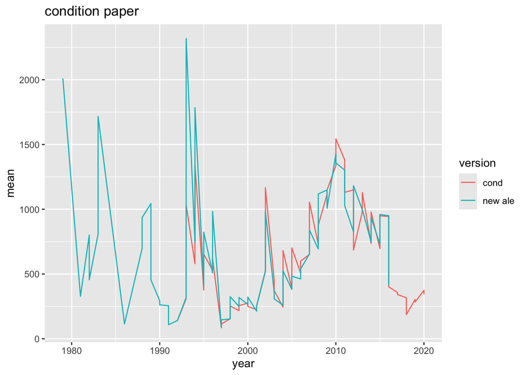

```r
# Plot comparison with previous script
library(patchwork)
d <- readr::read_csv("https://raw.githubusercontent.com/maxlindmark/cod_condition/master/data/for_analysis/catch_q_1_4.csv") |>
  mutate(sub_div = as.factor(sub_div))

# Summarise catches by haul
COD3_sum <- COD2 |>
  tidylog::summarise(biomass_density = sum(biomass_density), .by = haul_id) |>
  tidylog::left_join(
    COD2 |>
      dplyr::select(
        year, sub_div, haul_id, length_class, species, ices_rect,
        date, lat, lon, source
      ) |>
      distinct(haul_id, .keep_all = TRUE),
    by = "haul_id"
  ) |>
  mutate(
    month = month(as_date(date)),
    quarter = quarter(as_date(date))
  ) |>
  drop_na(year) |>
  filter(sub_div %in% c(24, 25, 26, 27, 28)) |>
  filter(year >= 1979) |>
  summarise(mean = mean(biomass_density), .by = c(sub_div, year, quarter)) |>
  mutate(version = "new ale")

d_sum <- d |>
  filter(sub_div %in% c(24, 25, 26, 27, 28)) |>
  filter(year >= 1979) |>
  summarise(mean = mean(density), .by = c(sub_div, year, quarter)) |>
  mutate(version = "cond")

dd <- bind_rows(COD3_sum, d_sum)

dd |>
  filter(quarter %in% c(1, 4)) |>
  filter(sub_div == 25) |>
  ggplot(aes(year, mean, color = version)) +
  geom_line() +
  ggtitle("condition paper")
```